# neuro-521-2018-02-08

2018-02-08

## preliminaries

## Topics

- Visual processing in V1
- Object processing
- Perception vs. action
- **"Reading" the mind via fMRI**
- Does neuroscience need behavior?

## Resources

- Course web site: [psu-psychology.github.io/neuro-521-spring-2018](https://psu-psychology.github.io/neuro-521-spring-2018/schedule.html)

## Papers

- {When, If, Although} useful tool for starting an essay, but not obligatory.
- Short essays should have short introductions; put the nuts and bolts in the body.

## main event

## Today's reading

Kay, K. N., Naselaris, T., Prenger, R. J., & Gallant, J. L. (2008). Identifying natural images from human brain activity. *Nature*, *452*(7185), 352–355. https://doi.org/10.1038/nature06713. [Supplemental materials](http://www.nature.com/nature/journal/v452/n7185/extref/nature06713-s1.pdf).

## From static images to dynamic patterns

[video not shown]

Nishimoto, S., Vu, A. T., Naselaris, T., Benjamini, Y., Yu, B., & Gallant, J. L. (2011). Reconstructing Visual Experiences from Brain Activity Evoked by Natural Movies. Current Biology, 21(19), 1641–1646. https://doi.org/10.1016/j.cub.2011.08.031.

[figure not shown]

[Kay et al. 2008](https://doi.org/10.1038/nature06713), Fig 1

[figure not shown]

[Kay et al. 2008](https://doi.org/10.1038/nature06713), Fig 2

[figure not shown]

[Kay et al. 2008](https://doi.org/10.1038/nature06713), Fig 3

[figure not shown]

[Kay et al. 2008](https://doi.org/10.1038/nature06713), Fig 4

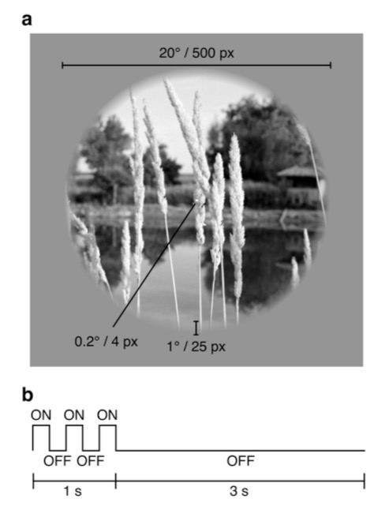

[Kay et al. 2008](https://doi.org/10.1038/nature06713), Supp Fig 1

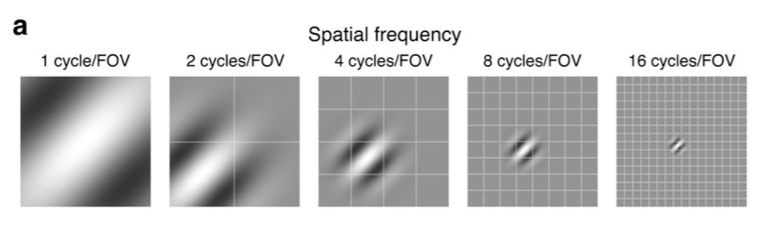

[Kay et al. 2008](https://doi.org/10.1038/nature06713), Supp Fig 2a

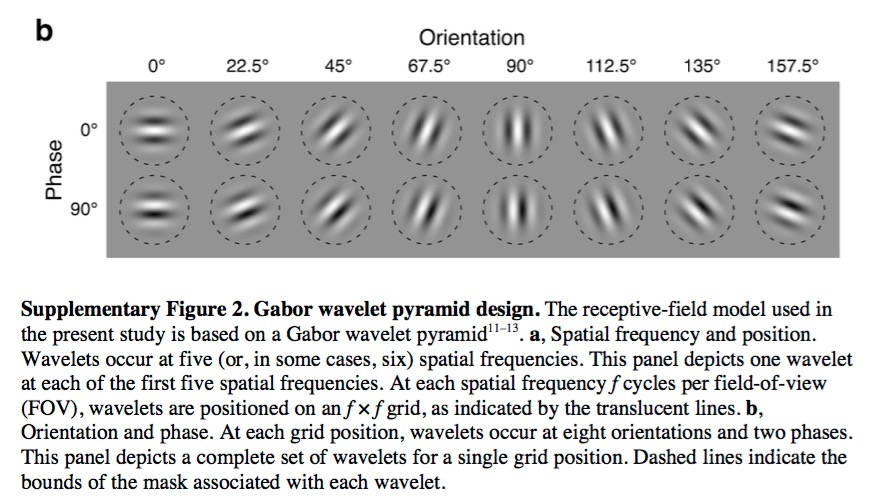

[Kay et al. 2008](https://doi.org/10.1038/nature06713), Supp Fig 2b

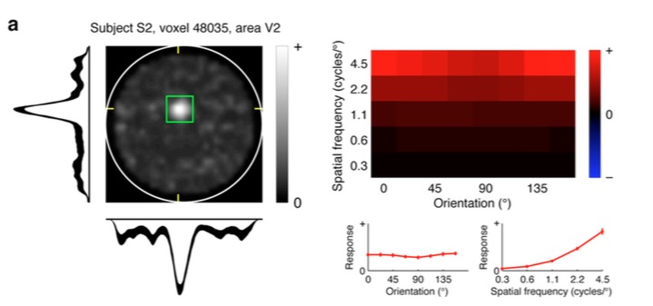

[Kay et al. 2008](https://doi.org/10.1038/nature06713), Supp Fig 9a

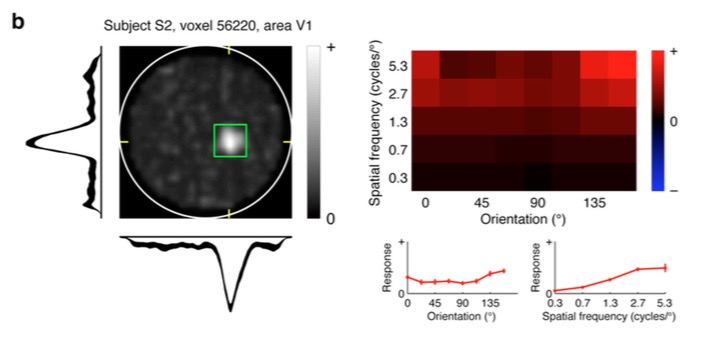

[Kay et al. 2008](https://doi.org/10.1038/nature06713), Supp Fig 9b

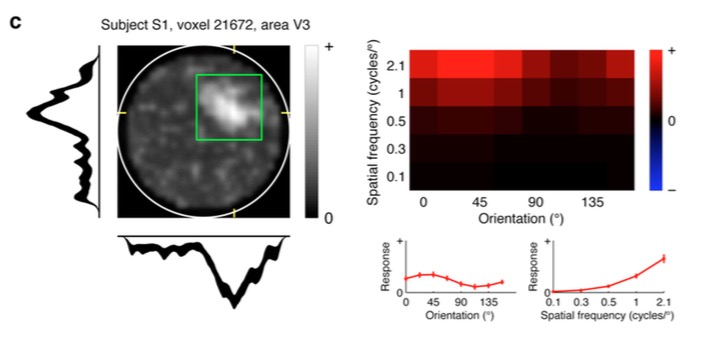

[Kay et al. 2008](https://doi.org/10.1038/nature06713), Supp Fig 9c

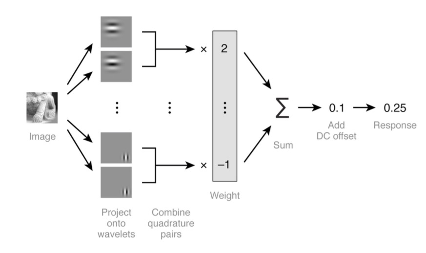

[Kay et al. 2008](https://doi.org/10.1038/nature06713), Supp Fig 3

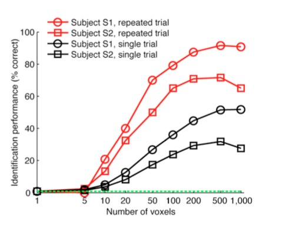

[Kay et al. 2008](https://doi.org/10.1038/nature06713), Supp Fig 4

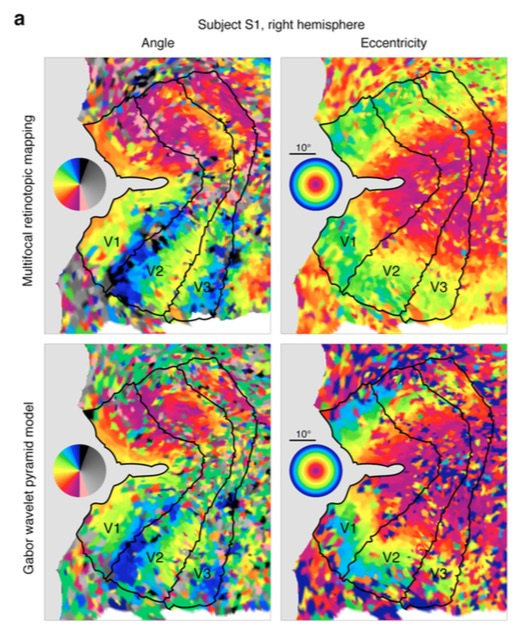

[Kay et al. 2008](https://doi.org/10.1038/nature06713), Supp Fig 10a

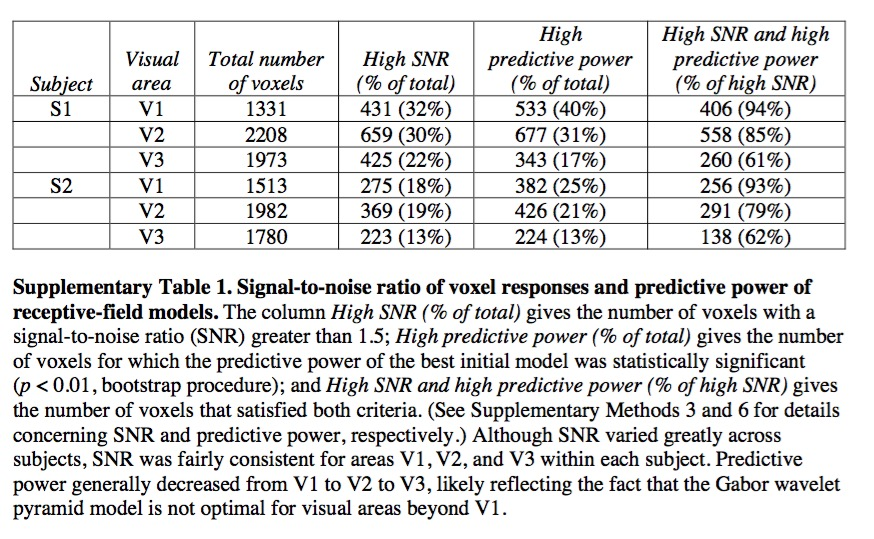

[Kay et al. 2008](https://doi.org/10.1038/nature06713), Supp Table 1

## Next time…

- Does neuroscience need behavior?

Krakauer, J. W., Ghazanfar, A. A., Gomez-Marin, A., MacIver, M. A., & Poeppel, D. (2017). Neuroscience needs behavior: Correcting a reductionist bias. *Neuron*, *93*(3), 480–490. Retrieved from http://dx.doi.org/10.1016/j.neuron.2016.12.041